# Zipf

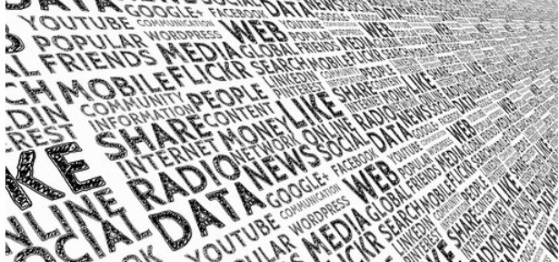

## Overview

In this assignment you will…

- Analyze word frequency.
- Learn about the concept of stop words.

## Tasks

### A - Return to previous assignment

1. Start a new markdown document and start out with working code from the previous assignment in order to tokenize the text.
2. At the beginning also load the package `stopwords`.

```r
library(readr)
library(stringr)
library(wordcloud)
library(stopwords)

# load text
text <- read_file('pg2197.txt')

# cut text into sections
text_split = str_split(text, '\\*{3}[:print:]*\\*{3}')

# count characters per section
nchar(text_split[[1]])
```

```
## [1]    502 338120      4   1299  17639
```

```r
# extract main text
main_text = text_split[[1]][2]

# to lower
main_text = str_to_lower(main_text)

# tokenize
tokens = str_extract_all(main_text, '[:alpha:]+')[[1]]
```

### B - Analyze frequencies

1. Begin analyzing the frequency distribution of tokens by counting the occurrences of each token using `table()`. The `table()`-function will return a table object that you can treat, for the most part, like a named integer vector. Store the resulting object as `token_frequencies`.

```r
# count tokens
token_frequencies = table(tokens)
```

2. Use `length()` to determine the length of `token_frequencies`. What does this number tell you?

```r
# count tokens
length(token_frequencies)
```

```
## [1] 5611
```

3. `token_frequencies` has one element for every unique token. It’s length therefore indicates the number of distinct tokens in the book. Print a few entries, e.g., `token_frequencies[1:100]`, to get a feel what those elements look like.

```r
# print first tokens
token_frequencies[1:100]
```

```
## tokens
##                a            aback        abandoned      abandonment
##             1393                2                2                2
##           abased        abasement           abated       aberration
##                1                4                1                1
##            abide          ability           abject             able
##                2                1                1               18
##            abode       abominable            about            above
##                5                1              141               10
##         abridged           abroad           abrupt          absence
##                1                5                3                3
##           absent       absolument         absolute       absolutely
##                6                1                7                2
##          absolve         absolves         absorbed      abstraction
##                1                1                1                1
##           absurd        absurdity         abundant            abuse
##                8                1                1                3
##           abused          abusive            abyss           accent
##                2                2                3                1
##          accents           accept         accepted        accepting
##                2                4                5                2
##         accident      accompanied        accompany     accompanying
##                2                5                4                1
##           accord       accordance         accorded        according
##                1                1                1                6
##      accordingly          account       accountant        accounted
##                3               10                1                1
##         accounts      accumulated         accursed      accusations
##                2                1                9                1
##           accuse       accustomed            ached           aching
##                1                1                1                1
##     acquaintance    acquaintances acquaintanceship       acquainted
##                8                3                1                1
##          acquire         acquired        acquiring      acquisition
##                1                3                3                1
##           across              act            acted           acting
##                3                8                4                5
##           action          actions           actors          actress
##                5                1                1                1
##             acts           actual         actually          acutely
##                2                6               16                1
##          adamson              add            added         addicted
##                1                2               34                1
##         addition       additional          address        addressed
##                4                1                3                3
##        addressee        addresses       addressing          adhered
##                1                1                1                1
##         adjacent        adjoining          adjourn       administer
##                1                3                1                1
##            admit            adopt          adopted          adorned
##                3                1                3                1
```

4. Use `sort()` with `decreasing = TRUE` to arrange the elements of `token_frequencies` in descending order. Store the sorted table again as `token_frequencies` (i.e., overwrite the object).

```r
# sort token table
token_frequencies = sort(token_frequencies, decreasing = TRUE)
```

### C - Zipf’s law

1. Analyze token frequency as a function of the token’s rank and label the axes as `"Token rank"` and `"Token frequency"`. To do this, create two vectors, one called `token_rank` containing the token ranks (use `rank()`), where the smallest rank is assigned to the token with the highest frequency, and one called `token_freq` containing the token frequencies as a vector (use `c()`).

```r
# Create vectors
token_rank = rank(-token_frequencies)
token_freq = c(token_frequencies)
```

2. Now plot `token_freq` against `token_rank` as a line and label the axes as `"Token rank"` and `"Token frequency"`. Use the standard `plot()` function with `type = "l"`.

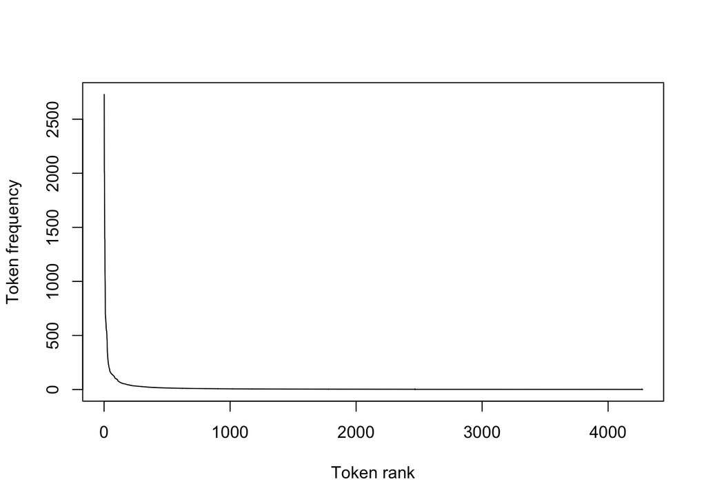

```r
# Plot Zipf
plot(token_rank, token_freq,
     type = "l", xlab = "Token rank", ylab = "Token frequency")
```

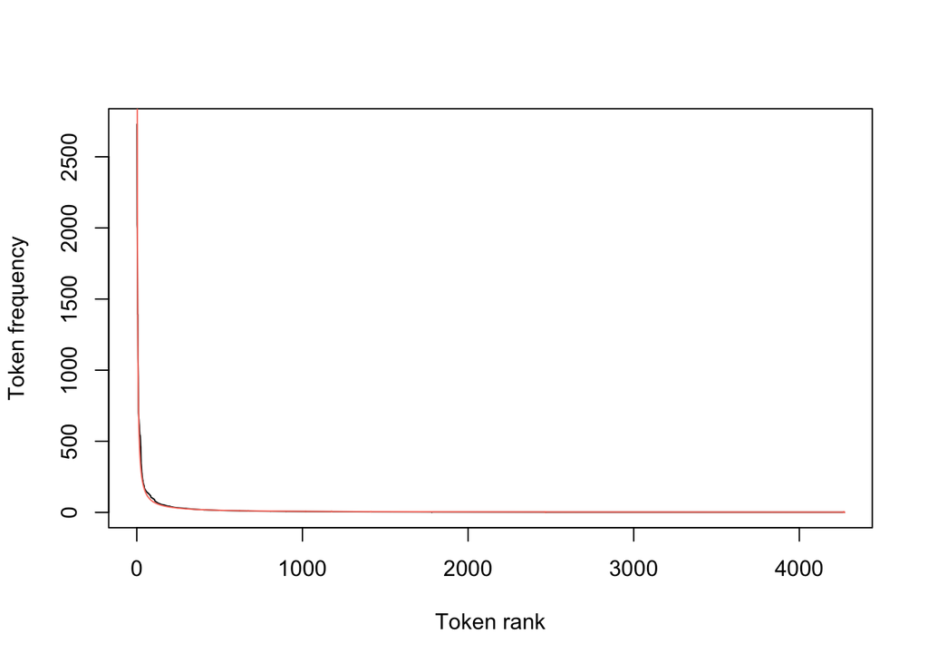

```r
# Add model
plot(token_rank, token_freq,
     type = "l", xlab = "Token rank", ylab = "Token frequency")
lines(token_rank, max(token_freq) * (1 / token_rank * 2.7), col = "salmon")
```

4. The two lines should have overlapped relatively well. This should be even easier to see using a log-scaled visualization. Try it out. Simply add `log = "xy"` as an the plot function.

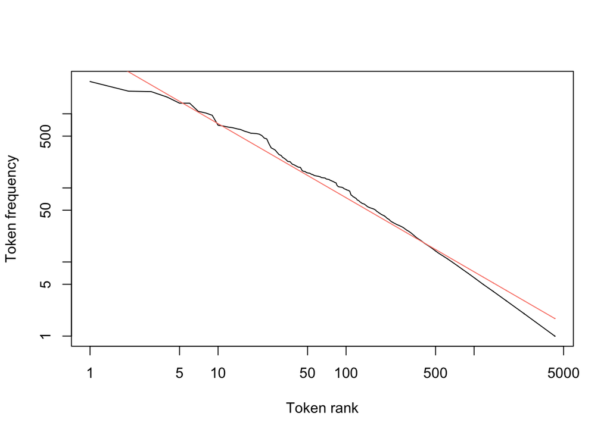

```r
# Add model
plot(token_rank, token_freq,
     type = "l", xlab = "Token rank", ylab = "Token frequency", log="xy")
lines(token_rank, max(token_freq) * (1 / token_rank * 2.7), col = "salmon")
```

### D - Zipf’s part II

1. Another law related to the one just studied and also associated with Zipf is the relationship betweenw word length and frequency. Using `names()` and `nchar()`, create a new vector from `token_frequencies` containing the number of characters of each of the tokens. Call this vector `token_nchar`.

```r
# Create vector of characters
token_nchar = nchar(names(token_frequencies))
```

2. Using `plot()`, plot `token_freq` against `token_nchar` as points (i.e., don’t use `type = "l"`).

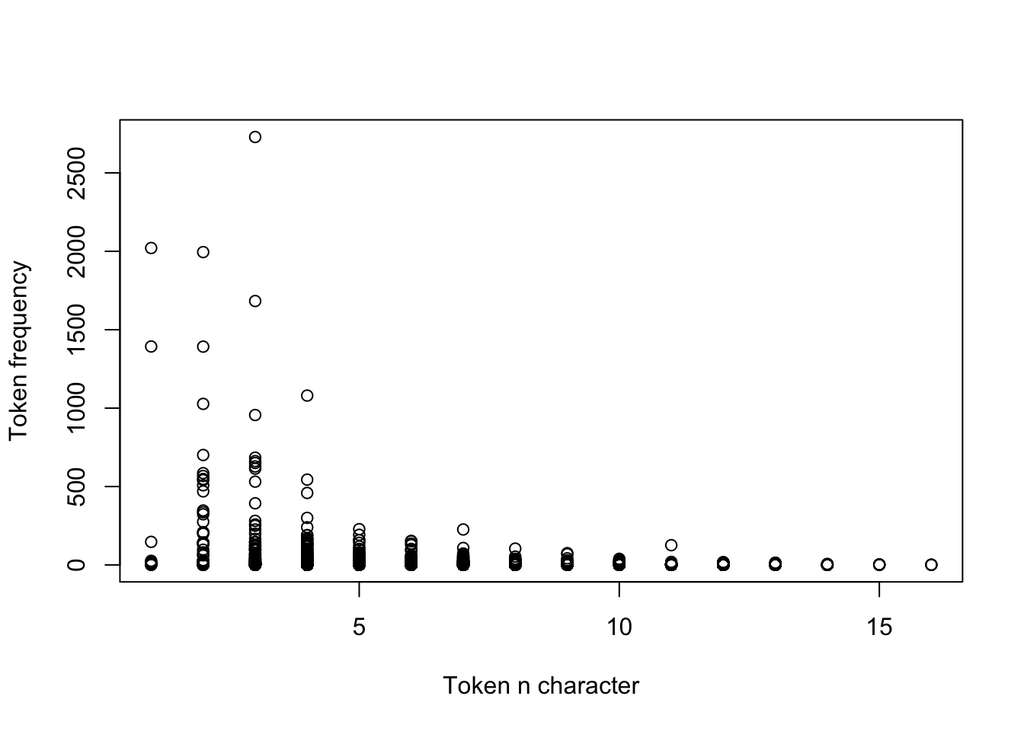

```r
# Plot Zipf pt. II
plot(token_nchar, token_freq,
     xlab = "Token n character", ylab = "Token frequency")
```

3. Is there a relationship between the number of characters in a token and it’s frequency? What does this reveal about language?

### D - Stopwords

1. Extremely frequent words are usually less interesting because they occur in so many different context that they cannot carry a lot of meaning. For many analyses focusing on meaning or content, it is common to eleminate such overly frequent words devoid of specific meaning, which are known as stopwods. Use `stopwords()` to create a vector called `stopwords`.
2. Take a look at `stopwords` by printing it. Which kind of words are included in the vector?
3. Determine the average rank of the words in `stopwords` based on `token_frequencies`. This code snippet should be useful `names(token_frequencies) %in% stopwords`. Does this confirm the high frequency of stop words?

```r
# stopwords
stopwords = stopwords()

# average rank
token_rank[names(token_frequencies) %in% stopwords] %>%
  mean(na.rm = T)
```

```
## [1] 190.6585
```